# Climate Change Module

## What controls the temperature of an object?

- Incoming energy
- Outgoing energy
- The heat capacity of the object (how much energy is needed to heat a degree)
- Incoming > Outgoing = warming
- Incoming < Outgoing = cooling

## What controls Earth’s temperature?

- Incoming: energy received by the sun
- Outgoing: reflection of sun’s energy (albedo)
- Outgoing: Energy released by Earth
- Net: The amount of energy retained by the earth’s atmosphere.

## Amount of energy received from the sun

- Sunspots – reflect the magnetic activity of the sun and the sun’s brightness.
- Approximately an 11-year cycle
- Not getting brighter over last 30 years

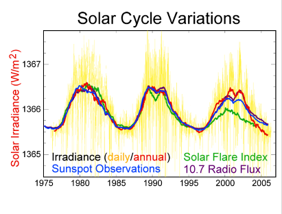

## Amount of energy received by the sun

- The path of the earth around the sun and the earth’s angle vary at different time scales.
- Has been an important influence for glacial periods (every 100,000 years) over the past 500,000 years.
- Milankovitch Cycles

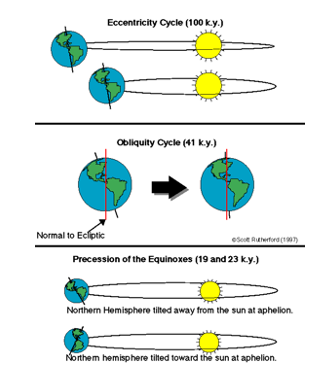

## Amount of energy reflected to space

- Albedo (reflectivity)
- Lighter things reflect more light energy
- Darker things absorb more light energy (heat)
- Creates positive feedback
- Aerosols lead to increased reflection of solar radiation (Volcanic activity -> cooling).

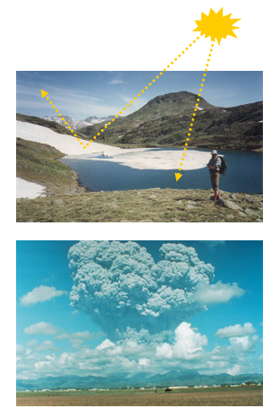

## Amount of energy retained by the atmosphere

- Solar energy absorbed by land/oceans is converted into heat
- Objects with heat release energy in proportion to their heat
- Sun = HOT, Earth = Not Hot, so energy release by energy is different than heat released by sun

## Amount of energy retained by the atmosphere

- The greenhouse effect: Some of energy in the form released by earth surface is absorbed by the atmosphere
- Gases in the atmosphere trap heat (H20, CO2, CH4, NOxs, CFCs)
- Trapped heat is remitted by the atmosphere towards the surface
- Now the surface is heated by sun and the energy from the gases in the atmosphere
- Greenhouse effect is good because earth would be too cold without it!
- But changing due to changing gases in the atmosphere

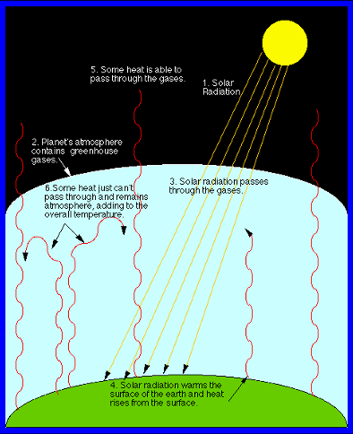

## Global energy balance

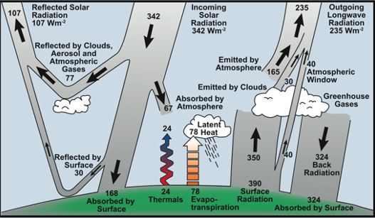

## Why does climate change matter?

- Climate has always changed and will always change
- Historically major climate change has been associated with massive changes in life on earth
  - Alaska was subtropical when early humans cross the land-bridge
  - The entire Earth has been cover with ice in the past
  - If change is faster than life can adapt or evolve, then challenging for current life

## Why does climate change matter?

- Do we want to want live in the warmer world?
  - What does a warmer world look like? (Impacts)
  - Winners and losers
- If humans are causing it, then we can stop causing it.
  - Should we? At what costs?
  - Winners and losers

## Data: What is “global temperature”?

Global surface temperature is calculated by averaging the temperatures over sea and land. Communicated as an anomaly.

[figure not shown]

## Data: What is “global temperature”?

- Many groups across the world have generated datasets of global temperature
- One example: Hansen et al. 2010 from Goddard Institute for Space Studies, NASA http://pubs.giss.nasa.gov/docs/2010/2010_Hansen_etal_1.pdf
- Different datasets from weather stations all over the world were compiled.
- Used a model to interpolate (smooth) data for land
- Use bucket (ships) and satellite measurements calibrated with ship measurements for the ocean

## What would cause global temperature to change?

- Sun increasing output (Not likely)
- Earth relatively closer to the sun (not the current cycle)
- Color of the earth getting darker (actually getting brighter due to agriculture)
- More greenhouse gasses in the atmosphere (👈)
  - Primarily from fossil fuel composition

## How do we measure atmospheric CO2?

- Dr. Dave Keeling started measuring the CO2 concentration in air in 1958
- Collected air in vacuum-cleared glass flasks and measured CO2 content
- Still measured with the method today (as well as sensors)

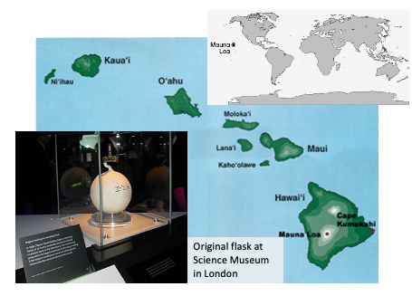

## How do current changes compare to past climate?

- The earth is 4.54 billion years old
- The last ice age was 110,000 to 12,000 years ago, with peak glaciation 22,000 years ago
- The world looked different!
  - Northern USA and Canada covered by ice
  - Southern US covered by taiga (coniferous forest) and grassland
  - Southern Europe was tundra

## Ice cores!

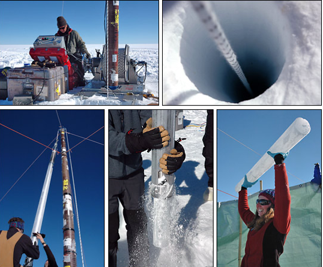

## Ice cores!

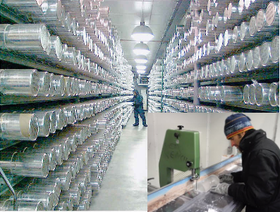

## Ice cores!

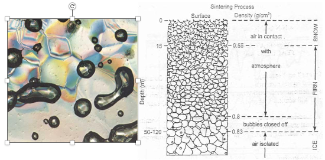

## Key questions in module

- What is the evidence for a changing climate?
- How do find & interpret data sources behind leading climate change indicators?
- How do we read and plot this data in a scriptable & reproducible manner?
- How do we communicate technical analysis in notebook formats that combine code, text, and visuals?

## Key Data Science Objectives

- Reading data with diverse and unexpected formats
- Searching for how to solve problems
- Question 10 has more independence when addressing a question with data.